# Long-term dynamics of catfish diet

В. М. Хайтов

2024-04-11

## Часть 1. Сезонная и многолетняя динамика частоты пустых кишечников

Для этого анализабыла построена обобщенная логистическая аддитивная модель (generalized additive model, **GAM 1**), описывающая связь вероятности встречи рыб с пустыми кишечниками с тремя пердикторами: пол (Sex), номер календарного дня от начала года (DOY, описывает сезонную динамику) и год (Year, описывает многолетнюю динамику). Зависимая переменная для этой модели кодировалсь, как 1, если рыба имела пустой кишечник, или, как 0, если в кишечникие содержалась пища).

Построенная модель описывается следующей формулой:

$$GAM1: Outcome = b_0 + b_1Sex_{Male} + f_1(DOY|Sex) + f_2(Year) +
\varepsilon$$
где $b_0$, $b_1$ параметрические парметры регрессии, для фактора Sex градация “Fimale” взята за базовый уовень.

$f_1$ - Непараметрическая сглаживающая функция, пододранная как множество кубических сплайнов (количество узлов 6), описывющая изменение частоты пустых кишечников в зависимсоти от DOY для каждого пола отдельно.

$f_2$ - Непараметрическая сглаживающая функция, пододранная как множество кубических сплайнов (количество узлов 6), описывющая изменение частоты пустых кишечников в зависимсоти от Year без учета пола).

Здесь и далее подбор параметров модели осуществлялся с помощью функции gam() из пакета “mgcv” (Wood, 2017).

Во результаты подбора этой модели

Таблица +. Описание аддиивной модели, описвающей сезонную и многолетнюю частоту пустых кишечников.

| term | edf | statistic | p.value |
| --- | --- | --- | --- |
| s(DOY):Sexfemale | 1.000423 | 7.183059 | 0.0073804 |
| s(DOY):Sexmale | 1.000195 | 2.319201 | 0.1278000 |
| s(Year) | 4.961386 | 60.355039 | 0.0000000 |

Важно! Для самцов значимой сезонной динамики нет. А вот у самок - да, есть значимое сезонное изменение частоты пустых желудков.

Вот визуализация полученной модели.

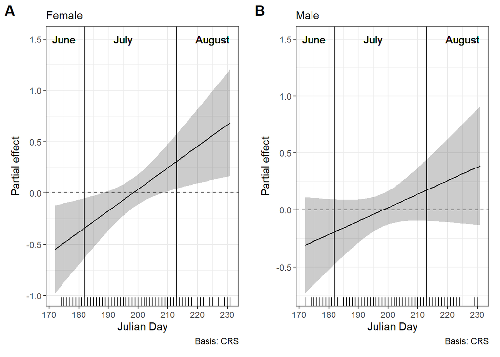

Рис. +. Сезонная динамика частоты особей с пустыми кишечниками среди самок (A) и самцов (B)

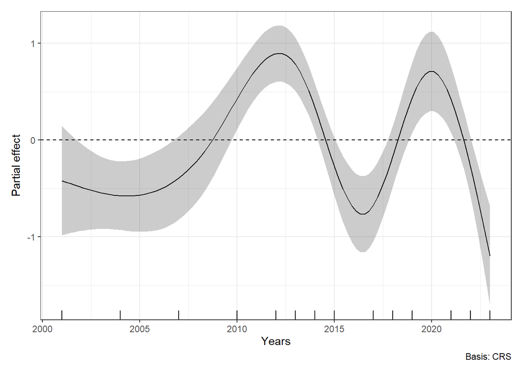

Рис. +. Многолетняя динамика частоты особей с пустыми кишечниками

Возможно пригодится еще и вот такая таблица. Она нужна в работе, так как весь дальнейший анализ идет без учета вероятности того, что рыба обнаружила пищу. А это, по-моему, важно.

| Year | Frequency of empty guts (%) |
| --- | --- |
| 2001 | 40.0 |
| 2004 | 39.6 |
| 2007 | 34.0 |
| 2010 | 59.6 |
| 2012 | 62.5 |
| 2013 | 69.8 |
| 2014 | 53.7 |
| 2015 | 36.1 |
| 2017 | 31.4 |
| 2018 | 52.7 |
| 2019 | 43.6 |
| 2021 | 53.5 |
| 2022 | 48.3 |
| 2023 | 17.2 |

## Часть 2. Динамика пищевого спектра

Для этого анализа были использованы только те рыбы, у которых в кишечнике обнаружены пищевые компоененты. Соответветственно, частоты расчитаны только среди тех рыб, которые получили пищу.

**Внимание!** Я по-прежнему не уверен, что так правильно. Еще раз аргументы. Связь рыбы с природным сообществом отражается тем, что рыба съела. Следовательно, встречаемость того или иного компонента (иными словами, веротность того, что рыба его съест), складывается из двух частей: $P_1$ - вероятность того, что рыба нашла пищевой объект (это $1-P_{empty}$) и $P_2$ - вероятность того, что рыба съест именно этот объект. Мы сейчас будем говорить только про вероятность $P_2$. Это либо надо открыто прописать, либо изменить ход анализа.

### Видовой состав пищевых объектов

Таблица +. Встречаемость видов в питании (%)

| Species | Freq |
| --- | --- |
| Buccinum_undatum | 50.2 |
| Serripes_groenlandicus | 32.4 |
| Mytilus_edulis | 16.4 |
| Arctica_islandica | 12.8 |
| Ciliatocardium_ciliatum | 12.3 |
| Styela_rustica | 10.7 |
| Pagurus_pubescens | 9.4 |
| Musculus_discors | 6.8 |
| Hyas_araneus | 6.6 |
| Littorina_littorea | 5.9 |
| Tonicella_marmorea | 5.9 |
| Cryptonatica_clausa | 3.2 |
| Modiolus_modiolus | 2.5 |
| Elliptica_elliptica | 2.1 |
| Astarte_borealis | 2.1 |
| Littorina_obtusata | 2.1 |
| Margarites_groenlandicus | 1.8 |
| Stongylocentrotus_pallidus | 1.6 |
| Astarte_montagui | 0.9 |
| Littorina_saxatilis | 0.9 |
| Sclerocrangon_boreas | 0.9 |
| Opiopholis_aculeata | 0.9 |
| Testudinalia_tesselata | 0.7 |
| Epheria_vincta | 0.7 |
| Crenella_decussata | 0.5 |
| Hiatella_arctica | 0.5 |
| Lyonsia_arenosa | 0.5 |
| Musculus_niger | 0.2 |
| Chlamys_islandica | 0.2 |
| Ariadnaria_borealis | 0.2 |
| Boreotrophon_truncatus | 0.2 |
| Margarites_olivaceus | 0.2 |
| Velutina_velutina | 0.2 |
| Margarites_helicinus | 0.2 |
| Stenosemus_albus | 0.2 |
| Boltenia_echinata | 0.2 |

### Динамика общего количества видов в питании зубатки

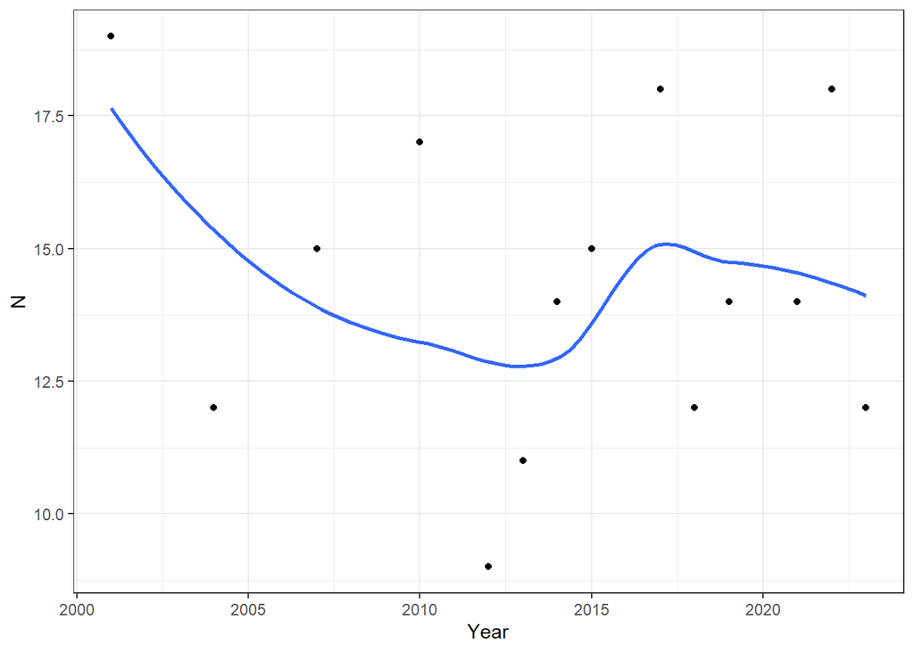

Рисунок +. Многолетние изменения общего количества видов, отмеченных в питании

Я предлагаю этот результат свсти в общую таблицу вместе с частотой пустых, а не отражать графиком.

Таблица +. Количество видов, отмеченных в питании

| Year | N |
| --- | --- |
| 2001 | 19 |
| 2004 | 12 |
| 2007 | 15 |
| 2010 | 17 |
| 2012 | 9 |
| 2013 | 11 |
| 2014 | 14 |
| 2015 | 15 |
| 2017 | 18 |
| 2018 | 12 |
| 2019 | 14 |
| 2021 | 14 |
| 2022 | 18 |
| 2023 | 12 |

### Динамика количества видов, имеющих высокую встречаемость

За порог взял частоту в 25%.

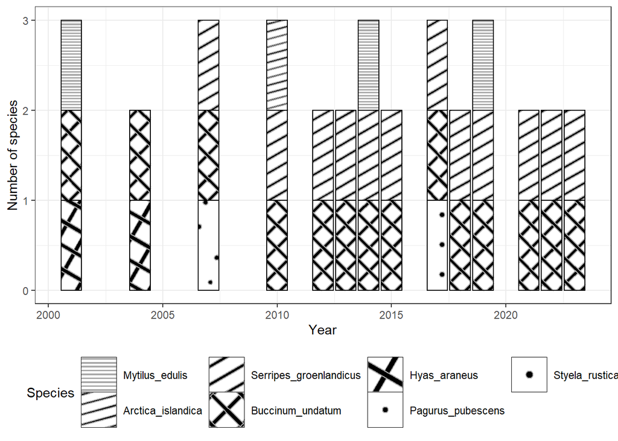

Рисунок +. Многолетние изменения соотношения частот видов, имеющих высокую встречаемость.

За порог взял частоту в 20%.

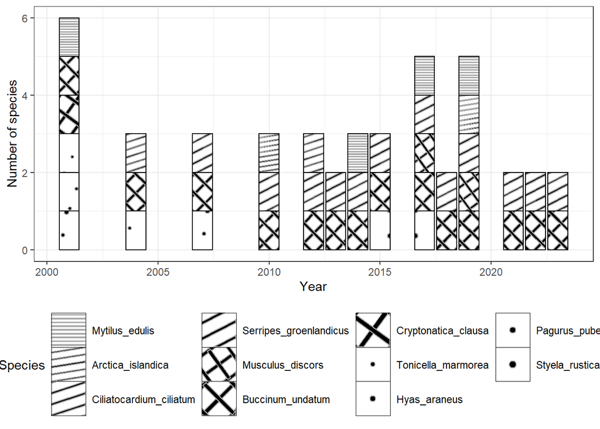

Рисунок +. Многолетние изменения соотношения частот видов, имеющих высокую встречаемость.

Паттерн заливки потом подкрутим. Пока не супер смотрится. Но проблема в том, что слишком много градаций.

То, что сумма больше 1 не должно смущать, так как в одном желудке может быть несколько разных видов.

### Индекс разнообразия пищевого спектра

Для описания разнообразия пишевого спектра был спользован индекс Шеннона, который в данном случае описывается следующей формулой.

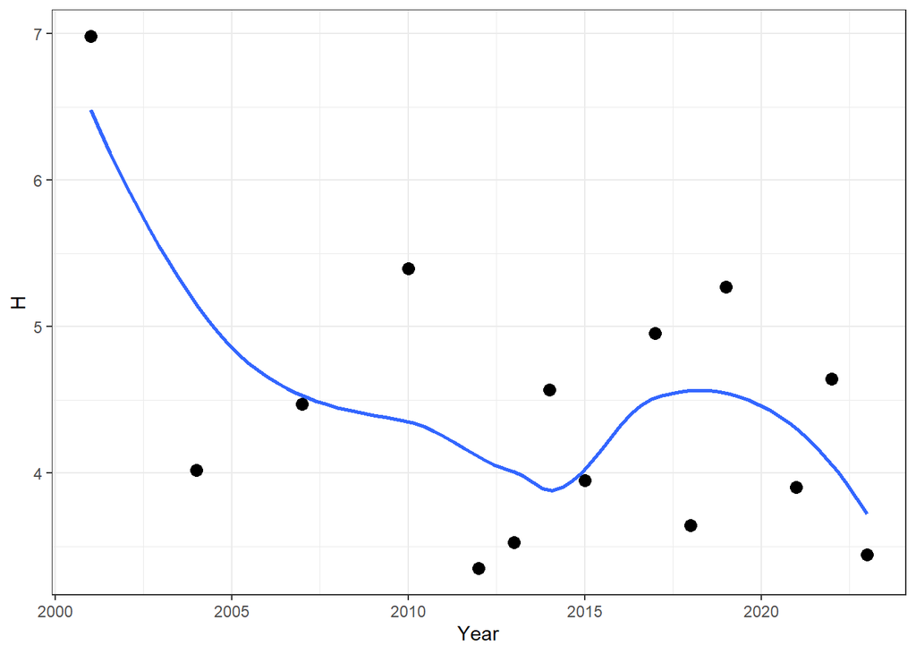

Рисунок +. Многолетние изменения индекса разнообразия. Кривая - линия тренда, подобранная методом LOESS.

Падение значений индекса говорит о снижении разнообразия пищевого спектра, что может отражать снижение разнообразия сообщества, в котором питается рыба. Это, в принципе, согласуется с тем, что рассматривается как причина изменений встречаемости отдельных видов (см. ниже).

## Динамика частоты отдельных видов в питании зубатки

Для дальнейшего анализа было отобрано 11 видов, встречаемость которых превышала 5%. Если вид был отмечен в питании, то переменная отклика кодировалась, как единица, если отсутствовал, то ноль.

На основе данных по этим видам была построена логистическая аддитивная модель (GAM2) следущего вида.

$$GAM2: Outcome = f(Year_i|Species_k) + b_0 + \sum b_kSpecies_k +
\varepsilon_i$$
где $f$ - непараметрические сглаживающие функции (подоранные как множество кубических сплайнов), описывющие связь вероятности встретить каждый отдельный вид с годом.

### Результаты построения модели

#### Оценка сглаживающих функций

| term | edf | statistic | p.value |
| --- | --- | --- | --- |
| s(Year):SpeciesMytilus_edulis | 3.232875 | 7.1634134 | 0.1248882 |
| s(Year):SpeciesArctica_islandica | 1.000057 | 0.2916802 | 0.5891989 |
| s(Year):SpeciesCiliatocardium_ciliatum | 1.000370 | 3.6776889 | 0.0551954 |
| s(Year):SpeciesSerripes_groenlandicus | 2.266850 | 8.9080763 | 0.0217546 |
| s(Year):SpeciesMusculus_discors | 2.790712 | 8.8014054 | 0.0433540 |
| s(Year):SpeciesBuccinum_undatum | 1.000610 | 3.2754812 | 0.0704742 |
| s(Year):SpeciesLittorina_littorea | 1.504882 | 9.4216369 | 0.0060055 |
| s(Year):SpeciesTonicella_marmorea | 1.539365 | 8.9140625 | 0.0196253 |
| s(Year):SpeciesHyas_araneus | 1.522513 | 49.6145963 | 0.0000000 |
| s(Year):SpeciesPagurus_pubescens | 1.000323 | 9.8095006 | 0.0017396 |
| s(Year):SpeciesStyela_rustica | 3.421483 | 18.8233317 | 0.0010440 |

Значимые межгодовые изменения были отмечены у следующих видов Serripes_groenlandicus, Musculus_discors, Littorina_littorea, Tonicella_marmorea, Hyas_araneus, Pagurus_pubescens, Styela_rustica.

#### Визуализация модели, описывающей многолетнюю динамику

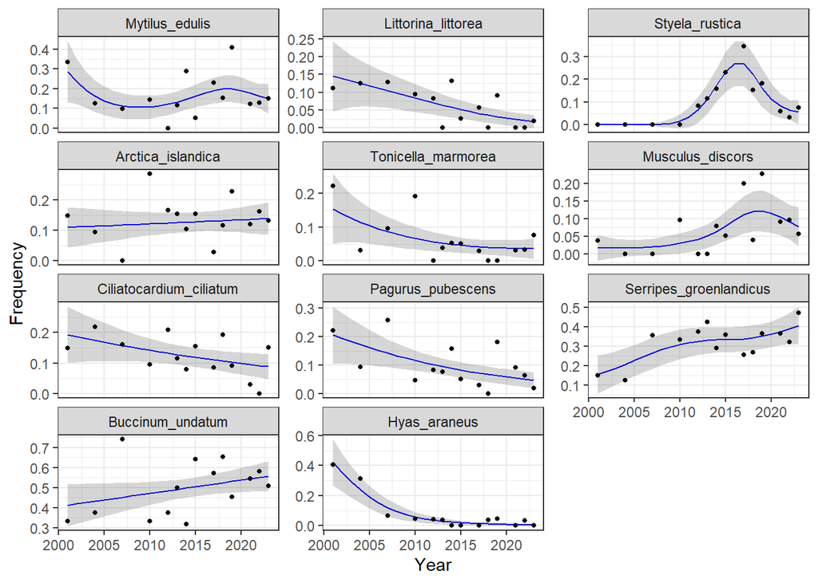

Рисунок +. Многолетние изменения встречаемости самых частых видов корма. Кривая - линия тренда, подобранная методом GAM.